# Ta-na-mesa: CNAE

Red Flag - CNAEs incomuns do Rio Grande do Sul (entre 2018 e 2020).

### Visão geral

A Classificação Nacional de Atividades Econômicas (CNAE) é uma definição utilizada nacionalmente e visa categorizar quais são as atividades econômicas exercidas por uma empresa. Essas empresas, podem fornecer uma diversidade de itens/produtos para o governo. No entanto, o fornecimento desses itens pode não ser frequente em determinadas categorias econômicas.

Este relatório tem como objetivo avaliar e identificar itens que não são frequentemente distribuídos pela categoria econômica da empresa fornecedora.

### Análise

Os dados utilizados na análise são de compras relacionadas a alimentação escolar do Rio Grande do Sul (entre 2018 e 2020).

#### Desafios

Abaixo estão elencados os principais desafios para avaliar os itens presentes na base de dados:

- Não existe um identificador único para cada item do contrato. Sendo assim, foi necessário agrupar todos os itens via similaridade (em torno de 2h para realizar esse processamento);
- Existem itens que não foram devidamente agrupados devido baixa qualidade da descrição.

#### CNAEs e itens de alimentação escolar

- CNAES Fiscais frequentes

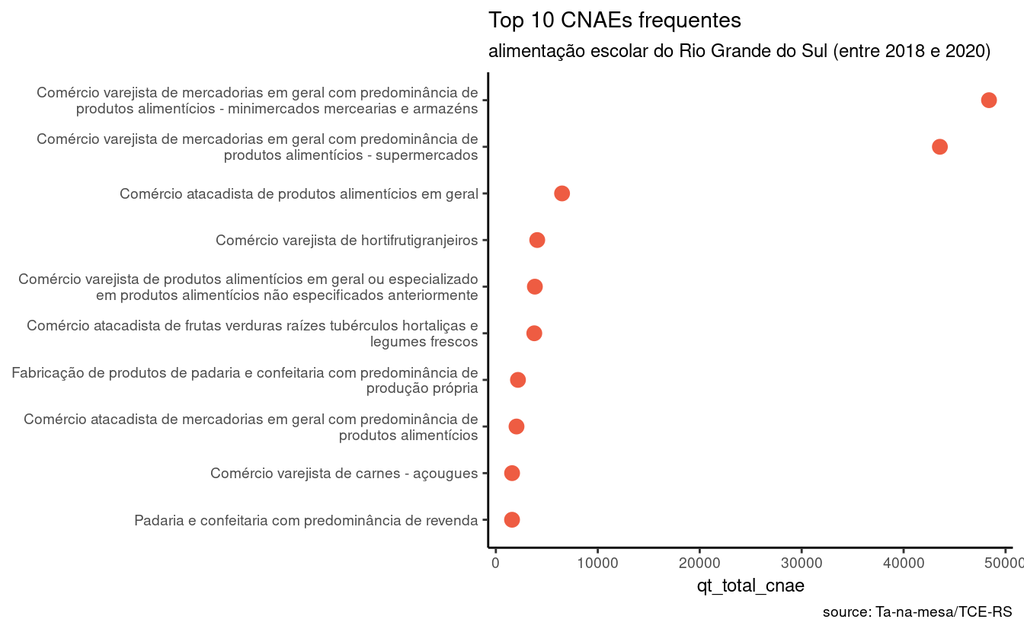

- Alguns CNAEs fiscais não relacionados a alimentação escolar

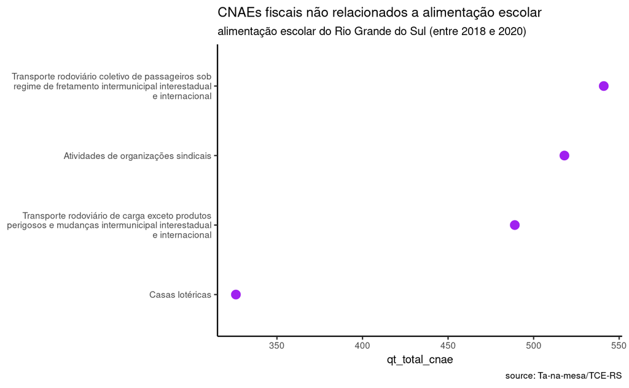

- Frequência dos CNAEs fiscais e secundários por item:

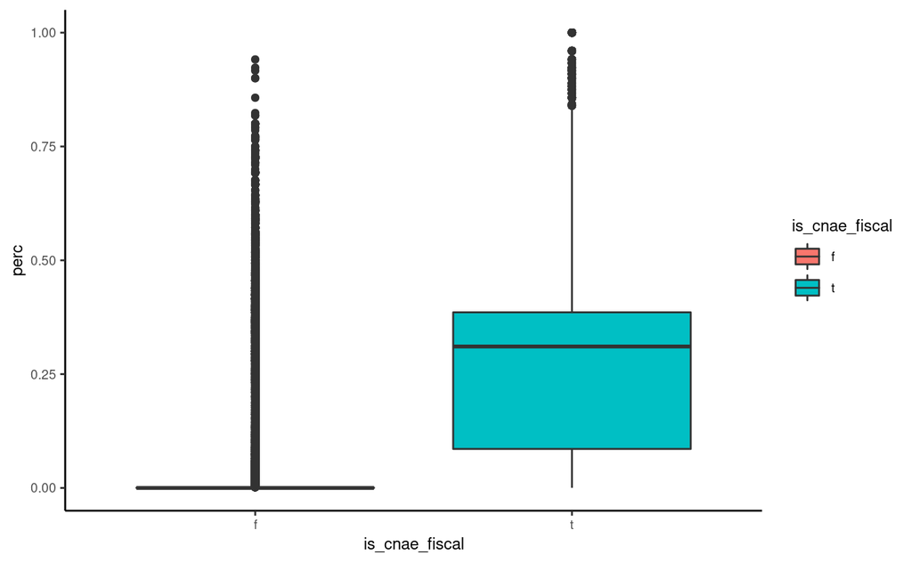

Exemplo de CNAE fiscal comum ([contrato](https://ta-na-mesa-validacao.herokuapp.com/compras/0bbb79cf50dd8d28d93a37764cb5f207) e [fornecedor](https://ta-na-mesa-validacao.herokuapp.com/fornecedores/06087823000182)):

|  | id_cnae | razao_social | nr_documento_contratado | is_cnae_fiscal | nm_cnae | item_class | perc |
| --- | --- | --- | --- | --- | --- | --- | --- |
| 1 | 4711302 | ROZILEIA PERETTO DENTI & CIA LTDA | 06087823000182 | t | Comércio varejista de mercadorias em geral com predominância de produtos alimentícios - supermercados | QUEIJO MUSSARELA FATIADO | 0.31 |
| 2 | 1091102 | ROZILEIA PERETTO DENTI & CIA LTDA | 06087823000182 | f | Fabricação de produtos de padaria e confeitaria com predominância de produção própria | QUEIJO MUSSARELA FATIADO | 0.02 |
| 3 | 4722901 | ROZILEIA PERETTO DENTI & CIA LTDA | 06087823000182 | f | Comércio varejista de carnes - açougues | QUEIJO MUSSARELA FATIADO | 0.00 |
| 4 | 4781400 | ROZILEIA PERETTO DENTI & CIA LTDA | 06087823000182 | f | Comércio varejista de artigos do vestuário e acessórios | QUEIJO MUSSARELA FATIADO | 0.00 |
| 5 | 4784900 | ROZILEIA PERETTO DENTI & CIA LTDA | 06087823000182 | f | Comércio varejista de gás liqüefeito de petróleo (GLP) | QUEIJO MUSSARELA FATIADO | 0.00 |
| 6 | 4930202 | ROZILEIA PERETTO DENTI & CIA LTDA | 06087823000182 | f | Transporte rodoviário de carga exceto produtos perigosos e mudanças intermunicipal interestadual e internacional | QUEIJO MUSSARELA FATIADO | 0.00 |

Exemplo onde o CNAE mais frequente não é o fiscal ([contrato](https://ta-na-mesa-validacao.herokuapp.com/compras/66f2fbd4bf10e1178272942f068effad) e [fornecedor](https://ta-na-mesa-validacao.herokuapp.com/fornecedores/15156051000184)):

|  | id_cnae | razao_social | nr_documento_contratado | is_cnae_fiscal | nm_cnae | item_class | perc |
| --- | --- | --- | --- | --- | --- | --- | --- |
| 1 | 4712100 | LOPES & BUENO LTDA | 15156051000184 | f | Comércio varejista de mercadorias em geral com predominância de produtos alimentícios - minimercados mercearias e armazéns | sal 1 kg | 0.43 |
| 2 | 4929902 | LOPES & BUENO LTDA | 15156051000184 | t | Transporte rodoviário coletivo de passageiros sob regime de fretamento intermunicipal interestadual e internacional | sal 1 kg | 0.12 |
| 3 | 2330302 | LOPES & BUENO LTDA | 15156051000184 | f | Fabricação de artefatos de cimento para uso na construção | sal 1 kg | 0.00 |
| 4 | 3702900 | LOPES & BUENO LTDA | 15156051000184 | f | Atividades relacionadas a esgoto exceto a gestão de redes | sal 1 kg | 0.00 |
| 5 | 4211101 | LOPES & BUENO LTDA | 15156051000184 | f | Construção de rodovias e ferrovias | sal 1 kg | 0.00 |
| 6 | 4213800 | LOPES & BUENO LTDA | 15156051000184 | f | Obras de urbanização - ruas praças e calçadas | sal 1 kg | 0.00 |

Exemplo onde nenhum dos CNAES são frequentes ([contrato](https://ta-na-mesa-validacao.herokuapp.com/compras/b8a01d6ceb9cd02931b82d6f8911a36e) e [fornecedor](https://ta-na-mesa-validacao.herokuapp.com/fornecedores/18835040000119)):

|  | id_cnae | razao_social | nr_documento_contratado | is_cnae_fiscal | nm_cnae | item_class | perc |
| --- | --- | --- | --- | --- | --- | --- | --- |
| 1 | 4619200 | SDT ASSESSORIA & REPRESENTACAO - EIRELI | 18835040000119 | f | Representantes comerciais e agentes do comércio de mercadorias em geral não especializado | Óleo de soja, 900ml | 0.0005611672 |
| 2 | 7020400 | SDT ASSESSORIA & REPRESENTACAO - EIRELI | 18835040000119 | t | Atividades de consultoria em gestão empresarial exceto consultoria técnica específica | Óleo de soja, 900ml | 0.0005611672 |
| 3 | 5250804 | SDT ASSESSORIA & REPRESENTACAO - EIRELI | 18835040000119 | f | Organização logística do transporte de carga | Óleo de soja, 900ml | 0.0000000000 |